# Routed Access Campus with Dual ISPs

Hands-on lab for Cisco IOL-XE 17.18.2 and Containerlab.

> **Method:** Build from outside inward. Configure one device section, run its checkpoint, then continue. Commands were selected for IOL-XE images used by this topology. Hardware forwarding, StackWise, EtherChannel hardware behavior, PoE, phone operation, and real ISP transit sit outside lab scope.

## Learning objectives

By end of lab, you will be able to:

- Read Containerlab-to-IOL interface mappings.
- Build routed campus access with no Layer 2 uplinks.
- Configure VLANs, SVIs, PortFast, and BPDU Guard at network edge.
- Form OSPF point-to-point adjacencies with passive-by-default operation.
- Divide OSPF into backbone Area 0 and totally stub Area 1.
- Summarize access routes at distribution ABRs.
- Use equal-cost OSPF paths for active/active uplinks.
- Build eBGP to two simulated ISPs and loopback-sourced iBGP between borders.
- Filter BGP routes with prefix lists and route maps.
- Enforce maximum-prefix limits and customer source validation.
- Translate private client addresses with border PAT.
- Prefer ISP1 outbound with LOCAL_PREF and de-prefer ISP2 inbound with AS-path prepending.
- Verify control plane, forwarding table, host reachability, and throughput.
- Break links and diagnose expected convergence.

## Lab workflow

| Phase | Devices | Build focus | Required gate |
| --- | --- | --- | --- |
| 0 | All nodes | Deploy, map interfaces, protect management | 15 nodes running |
| 1 | internet-r1 | Default origin and upstream policy | Two transit links up |
| 2 | isp1, isp2 | Customer/transit filtering and source validation | Upstream BGP Established |
| 3 | border-r1, border-r2 | OSPF, eBGP, iBGP, PAT, path policy | External and internal BGP Established |
| 4 | Core, distribution, access | OSPF areas, summary, ECMP, VLAN edge | Expected OSPF neighbor counts |
| 5 | Hosts and iperf | Data addressing and application tests | Campus and simulated-Internet reachability |
| 6 | Verification | Route, policy, NAT, and forwarding proof | Basic connectivity gate complete |
| 7 | Challenges | Controlled faults and recovery | Baseline restored after each challenge |

## Lab rules and limits

1. Do not configure Ethernet0/0. Containerlab reserves it for management.
2. IOL groups ports by four. eth4 maps to Ethernet1/0, not Ethernet0/4.
3. Save each IOS configuration after its checkpoint with write memory.
4. Generic Ubuntu VMs see Containerlab eth1 as ens2 on this image. Verify with ip -br link.
5. Host data interfaces use temporary Linux configuration. Redeploy removes it.
6. internet-r1 is isolated simulated upstream. It has no host or real-Internet data-plane link.
7. All public-looking addresses use RFC 5737 documentation blocks: 192.0.2.0/24, 198.51.100.0/24, and 203.0.113.0/24.
8. Border PAT translates client 10.1.0.0/23 to active WAN interface address. ISP source ACLs reject untranslated RFC1918 and spoofed customer traffic.
9. Shared upstream proves AS-path prepending: normal inbound path uses ISP1, then fails over to ISP2.
10. Voice VLAN SVIs remain down until at least one active Layer 2 port belongs to each voice VLAN. This is expected IOS SVI autostate behavior.

## Topology

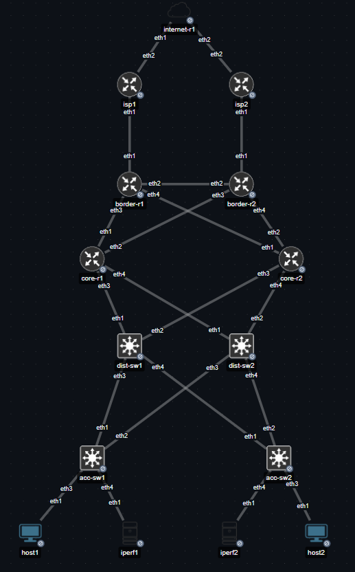

Physical and logical Containerlab links. Interface labels match topology endpoint names.

Routing roles:

| Layer | Devices | Function |
| --- | --- | --- |
| Upstream | internet-r1 | Isolated transit, default origin, public test loopback |
| ISP | isp1, isp2 | Filtered customer and upstream eBGP |
| Border | border-r1, border-r2 | eBGP, iBGP, OSPF default injection |
| Core | core-r1, core-r2 | OSPF Area 0 transit |
| Distribution | dist-sw1, dist-sw2 | OSPF ABR and Area 1 summarization |
| Access | acc-sw1, acc-sw2 | SVI gateways, routed uplinks, edge switching |
| Endpoint | host1, host2, iperf1, iperf2 | Reachability and throughput tests |

## Interface mapping

| Containerlab endpoint | IOL interface |
| --- | --- |
| eth0 | Ethernet0/0, management, do not configure |
| eth1 | Ethernet0/1 |
| eth2 | Ethernet0/2 |
| eth3 | Ethernet0/3 |
| eth4 | Ethernet1/0 |

On every IOL node, prove mapping before configuration:

```
show interfaces brief
show cdp neighbors
```

## Address plan

### WAN, border, and core

| Link | Network | Side A | Side B |
| --- | --- | --- | --- |
| isp1 - border-r1 | 192.0.2.0/30 | isp1 .1 | border-r1 .2 |
| isp2 - border-r2 | 198.51.100.0/30 | isp2 .1 | border-r2 .2 |
| isp1 - internet-r1 | 192.0.2.4/30 | isp1 .5 | internet-r1 .6 |
| isp2 - internet-r1 | 198.51.100.4/30 | isp2 .5 | internet-r1 .6 |
| border-r1 - border-r2 | 10.255.0.0/30 | border-r1 .1 | border-r2 .2 |
| border-r1 - core-r1 | 10.0.0.0/30 | border-r1 .1 | core-r1 .2 |
| border-r1 - core-r2 | 10.0.0.4/30 | border-r1 .5 | core-r2 .6 |
| border-r2 - core-r1 | 10.0.0.8/30 | border-r2 .9 | core-r1 .10 |
| border-r2 - core-r2 | 10.0.0.12/30 | border-r2 .13 | core-r2 .14 |
| core-r1 - dist-sw1 | 10.0.1.0/30 | core-r1 .1 | dist-sw1 .2 |
| core-r1 - dist-sw2 | 10.0.1.4/30 | core-r1 .5 | dist-sw2 .6 |
| core-r2 - dist-sw1 | 10.0.1.8/30 | core-r2 .9 | dist-sw1 .10 |
| core-r2 - dist-sw2 | 10.0.1.12/30 | core-r2 .13 | dist-sw2 .14 |

### Distribution, access, and endpoints

| Link or LAN | Network | Addresses |
| --- | --- | --- |
| dist-sw1 - acc-sw1 | 10.1.15.0/30 | dist .1, access .2 |
| dist-sw2 - acc-sw1 | 10.1.15.4/30 | dist .5, access .6 |
| dist-sw1 - acc-sw2 | 10.1.15.8/30 | dist .9, access .10 |
| dist-sw2 - acc-sw2 | 10.1.15.12/30 | dist .13, access .14 |
| VLAN 10 data | 10.1.0.0/25 | gateway .1, host1 .10, iperf1 .11 |
| VLAN 11 voice | 10.1.0.128/25 | gateway .129 |
| VLAN 20 data | 10.1.1.0/25 | gateway .1, host2 .10, iperf2 .11 |
| VLAN 21 voice | 10.1.1.128/25 | gateway .129 |

Loopbacks:

| Device | Loopback0 |
| --- | --- |
| internet-r1 | 192.0.2.200/32 |
| isp1 | 192.0.2.101/32 |
| isp2 | 198.51.100.101/32 |
| border-r1 | 10.0.255.1/32 |
| border-r2 | 10.0.255.2/32 |
| core-r1 | 10.0.254.1/32 |
| core-r2 | 10.0.254.2/32 |
| dist-sw1 | 10.0.253.1/32 |
| dist-sw2 | 10.0.253.2/32 |

## Step 0 - Deploy and baseline

### Isolation safety check

Topology data plane contains only explicit node-to-node links. internet-r1 is simulated upstream, not host uplink. Its default route terminates at Null0. Containerlab management bridge exists only for administration and is never used as routed transit.

Before configuration, verify IOL has no management-derived default:

```
show ip interface brief | include Ethernet0/0
show ip route 0.0.0.0
```

#### Expected state

Ethernet0/0 has Containerlab management address; default is not in routing table. Do not add NAT, OSPF, BGP, policy, or data-plane descriptions to Ethernet0/0.

From lab directory:

```bash
cd /opt/containerlab/labs/router-access-dual-isp
sudo clab deploy -t routed-access-dual-isp.clab.yml
sudo clab inspect -t routed-access-dual-isp.clab.yml
```

Connect to IOL nodes:

```bash
sudo clab connect -t routed-access-dual-isp.clab.yml --node border-r1
```

Connect directly by management name when SSH is ready:

```bash
ssh admin@clab-routed-access-dual-isp-border-r1
```

Baseline every IOS node:

```
show version
show interfaces brief
show cdp neighbors
show running-config | section router
```

#### Expected state

- Image reports IOS XE 17.18.2.
- Ethernet0/0 has management address.
- Data interfaces have no lab IP configuration.
- No OSPF or BGP process runs on clean deployment.

> **Destructive reset:** sudo clab destroy -t routed-access-dual-isp.clab.yml -c removes containers and generated lab directory, including saved node state. Use only when starting lab again.

# Device configuration

## Step 1 - internet-r1

**Open internet-r1 configuration and checkpoint**

### Goal

Create isolated upstream AS 64500. Advertise only default route to both ISPs. Accept only campus documentation prefix. Shared upstream makes inbound path selection observable.

### Configure

```
enable
configure terminal
hostname internet-r1
ip routing

interface Loopback0
 description SIMULATED-PUBLIC-SERVICE
 ip address 192.0.2.200 255.255.255.255
 exit

interface Ethernet0/1
 description TO-ISP1
 ip address 192.0.2.6 255.255.255.252
 no shutdown
 exit

interface Ethernet0/2
 description TO-ISP2
 ip address 198.51.100.6 255.255.255.252
 no shutdown
 exit

ip route 0.0.0.0 0.0.0.0 Null0
ip route 192.0.2.0 255.255.255.252 192.0.2.5
ip route 198.51.100.0 255.255.255.252 198.51.100.5

ip prefix-list CAMPUS-IN seq 5 permit 203.0.113.0/24
ip prefix-list TRANSIT-OUT seq 5 permit 0.0.0.0/0

route-map CAMPUS-IN permit 10
 match ip address prefix-list CAMPUS-IN
 exit

route-map TRANSIT-OUT permit 10
 match ip address prefix-list TRANSIT-OUT
 exit

router bgp 64500
 bgp router-id 192.0.2.200
 bgp log-neighbor-changes
 neighbor 192.0.2.5 remote-as 65001
 neighbor 192.0.2.5 description ISP1
 neighbor 192.0.2.5 route-map CAMPUS-IN in
 neighbor 192.0.2.5 route-map TRANSIT-OUT out
 neighbor 198.51.100.5 remote-as 65002
 neighbor 198.51.100.5 description ISP2
 neighbor 198.51.100.5 route-map CAMPUS-IN in
 neighbor 198.51.100.5 route-map TRANSIT-OUT out
 address-family ipv4
  network 0.0.0.0 mask 0.0.0.0
  neighbor 192.0.2.5 activate
  neighbor 192.0.2.5 maximum-prefix 1
  neighbor 198.51.100.5 activate
  neighbor 198.51.100.5 maximum-prefix 1
  exit-address-family
 exit
end
write memory
```

### Checkpoint

```
show ip interface brief
show ip route static
show ip route 192.0.2.2
show ip route 198.51.100.2
show ip bgp summary
show ip bgp 203.0.113.0
show ip bgp neighbors 192.0.2.5 advertised-routes
```

#### Expected state

upstream interfaces and local default work. BGP peers wait for ISP configuration.

## Step 2 - isp1

**Open isp1 configuration and checkpoint**

### Configure

```
enable
configure terminal
hostname isp1

interface Loopback0
 ip address 192.0.2.101 255.255.255.255
 exit

interface Ethernet0/1
 description TO-BORDER-R1
 ip address 192.0.2.1 255.255.255.252
 ip access-group CUSTOMER-SOURCE-GUARD in
 no shutdown
 exit

interface Ethernet0/2
 description TO-INTERNET-R1
 ip address 192.0.2.5 255.255.255.252
 no shutdown
 exit

ip prefix-list CUSTOMER-IN seq 5 permit 203.0.113.0/24
ip prefix-list CUSTOMER-OUT seq 5 permit 0.0.0.0/0
ip prefix-list UPSTREAM-IN seq 5 permit 0.0.0.0/0
ip prefix-list UPSTREAM-OUT seq 5 permit 203.0.113.0/24

ip access-list extended CUSTOMER-SOURCE-GUARD
 permit ip host 192.0.2.2 any
 permit ip 203.0.113.0 0.0.0.255 any
 deny ip any any log
 exit

route-map CUSTOMER-IN permit 10
 match ip address prefix-list CUSTOMER-IN
 exit
route-map CUSTOMER-OUT permit 10
 match ip address prefix-list CUSTOMER-OUT
 exit
route-map UPSTREAM-IN permit 10
 match ip address prefix-list UPSTREAM-IN
 exit
route-map UPSTREAM-OUT permit 10
 match ip address prefix-list UPSTREAM-OUT
 exit

router bgp 65001
 bgp router-id 192.0.2.101
 bgp log-neighbor-changes
 neighbor 192.0.2.2 remote-as 65000
 neighbor 192.0.2.2 description CAMPUS-BORDER-R1
 neighbor 192.0.2.2 route-map CUSTOMER-IN in
 neighbor 192.0.2.2 route-map CUSTOMER-OUT out
 neighbor 192.0.2.6 remote-as 64500
 neighbor 192.0.2.6 description INTERNET-R1
 neighbor 192.0.2.6 route-map UPSTREAM-IN in
 neighbor 192.0.2.6 route-map UPSTREAM-OUT out
 address-family ipv4
  neighbor 192.0.2.2 activate
  neighbor 192.0.2.2 maximum-prefix 1
  neighbor 192.0.2.6 activate
  neighbor 192.0.2.6 maximum-prefix 1
  exit-address-family
 exit
end
write memory
```

### Checkpoint

```
show ip interface brief
show ip bgp summary
show ip bgp 0.0.0.0
show ip bgp neighbors 192.0.2.2 advertised-routes
show ip bgp neighbors 192.0.2.6 advertised-routes
```

#### Expected state

upstream peer establishes. ISP learns default from AS 64500. Customer peer waits for border-r1. No RFC1918 or unrelated route passes policy.

> **Check your understanding:** Why use separate customer-facing and upstream-facing policies?

## Step 3 - isp2

**Open isp2 configuration and checkpoint**

### Goal

Create second filtered ISP AS 65002.

### Configure

```
enable
configure terminal
hostname isp2

interface Loopback0
 ip address 198.51.100.101 255.255.255.255
 exit

interface Ethernet0/1
 description TO-BORDER-R2
 ip address 198.51.100.1 255.255.255.252
 ip access-group CUSTOMER-SOURCE-GUARD in
 no shutdown
 exit

interface Ethernet0/2
 description TO-INTERNET-R1
 ip address 198.51.100.5 255.255.255.252
 no shutdown
 exit

ip prefix-list CUSTOMER-IN seq 5 permit 203.0.113.0/24
ip prefix-list CUSTOMER-OUT seq 5 permit 0.0.0.0/0
ip prefix-list UPSTREAM-IN seq 5 permit 0.0.0.0/0
ip prefix-list UPSTREAM-OUT seq 5 permit 203.0.113.0/24

ip access-list extended CUSTOMER-SOURCE-GUARD
 permit ip host 198.51.100.2 any
 permit ip 203.0.113.0 0.0.0.255 any
 deny ip any any log
 exit

route-map CUSTOMER-IN permit 10
 match ip address prefix-list CUSTOMER-IN
 exit
route-map CUSTOMER-OUT permit 10
 match ip address prefix-list CUSTOMER-OUT
 exit
route-map UPSTREAM-IN permit 10
 match ip address prefix-list UPSTREAM-IN
 exit
route-map UPSTREAM-OUT permit 10
 match ip address prefix-list UPSTREAM-OUT
 exit

router bgp 65002
 bgp router-id 198.51.100.101
 bgp log-neighbor-changes
 neighbor 198.51.100.2 remote-as 65000
 neighbor 198.51.100.2 description CAMPUS-BORDER-R2
 neighbor 198.51.100.2 route-map CUSTOMER-IN in
 neighbor 198.51.100.2 route-map CUSTOMER-OUT out
 neighbor 198.51.100.6 remote-as 64500
 neighbor 198.51.100.6 description INTERNET-R1
 neighbor 198.51.100.6 route-map UPSTREAM-IN in
 neighbor 198.51.100.6 route-map UPSTREAM-OUT out
 address-family ipv4
  neighbor 198.51.100.2 activate
  neighbor 198.51.100.2 maximum-prefix 1
  neighbor 198.51.100.6 activate
  neighbor 198.51.100.6 maximum-prefix 1
  exit-address-family
 exit
end
write memory
```

### Checkpoint

```
show ip route 0.0.0.0
show ip bgp summary
show ip bgp 0.0.0.0
```

#### Expected state

upstream peer establishes; customer peer waits for border-r2.

## Step 4 - border-r1

**Open border-r1 configuration and checkpoint**

### Goal

Join OSPF Area 0, peer with ISP1 using eBGP, peer with border-r2 using loopback-sourced iBGP, prefer ISP1 default with LOCAL_PREF 200, advertise only campus public test prefix, and PAT clients.

### Build interfaces and OSPF

```
enable
configure terminal
hostname border-r1
ip routing

interface Loopback0
 ip address 10.0.255.1 255.255.255.255
 ip ospf 1 area 0
 exit

interface Ethernet0/1
 description EBGP-TO-ISP1
 ip address 192.0.2.2 255.255.255.252
 ip nat outside
 no shutdown
 exit

interface Ethernet0/2
 description IBGP-TRANSIT-TO-BORDER-R2
 ip address 10.255.0.1 255.255.255.252
 ip nat inside
 ip ospf 1 area 0
 ip ospf network point-to-point
 no shutdown
 exit

interface Ethernet0/3
 description TO-CORE-R1
 ip address 10.0.0.1 255.255.255.252
 ip nat inside
 ip ospf 1 area 0
 ip ospf network point-to-point
 no shutdown
 exit

interface Ethernet1/0
 description TO-CORE-R2
 ip address 10.0.0.5 255.255.255.252
 ip nat inside
 ip ospf 1 area 0
 ip ospf network point-to-point
 no shutdown
 exit

router ospf 1
 router-id 10.0.255.1
 passive-interface default
 no passive-interface Ethernet0/2
 no passive-interface Ethernet0/3
 no passive-interface Ethernet1/0
 default-information originate
 exit
end
```

#### Design reason

- Point-to-point removes DR/BDR election from two-node routed links.
- Passive default advertises loopback but sends hellos only toward known routers.
- Conditional origination injects OSPF default only while routing table contains a default.

### Build BGP policy and peers

```
configure terminal
ip access-list standard NAT-SOURCES
 permit 10.1.0.0 0.0.1.255
 exit
ip nat inside source list NAT-SOURCES interface Ethernet0/1 overload

ip route 203.0.113.0 255.255.255.0 Null0

ip prefix-list ISP1-ACCEPT seq 5 permit 0.0.0.0/0
ip prefix-list CAMPUS-PREFIX seq 5 permit 203.0.113.0/24

route-map ISP1-IN permit 10
 match ip address prefix-list ISP1-ACCEPT
 set local-preference 200
 exit

route-map CAMPUS-OUT permit 10
 match ip address prefix-list CAMPUS-PREFIX
 exit

router bgp 65000
 bgp router-id 10.0.255.1
 bgp log-neighbor-changes
 neighbor 192.0.2.1 remote-as 65001
 neighbor 192.0.2.1 description ISP1
 neighbor 192.0.2.1 route-map ISP1-IN in
 neighbor 192.0.2.1 route-map CAMPUS-OUT out
 neighbor 10.0.255.2 remote-as 65000
 neighbor 10.0.255.2 description IBGP-BORDER-R2
 neighbor 10.0.255.2 update-source Loopback0
 neighbor 10.0.255.2 next-hop-self
 address-family ipv4
  network 203.0.113.0 mask 255.255.255.0
  neighbor 192.0.2.1 activate
  neighbor 192.0.2.1 maximum-prefix 1
  neighbor 10.0.255.2 activate
  exit-address-family
 exit
end
write memory
```

### Checkpoint

```
show ip ospf interface brief
show ip ospf neighbor
show ip bgp summary
show ip bgp neighbors 192.0.2.1 routes
show ip bgp neighbors 192.0.2.1 advertised-routes
show ip bgp 0.0.0.0
show ip prefix-list
show route-map
show ip nat statistics
show ip nat translations
```

#### Expected state

- ISP1 eBGP reaches Established and default has local preference 200.
- iBGP waits until border-r2 loopback becomes reachable through OSPF.
- Outbound advertisement contains 203.0.113.0/24 only.
- No OSPF neighbor forms on ISP-facing Ethernet0/1.

> **Check your understanding:** Why is conditional default origination safer than always?

## Step 5 - border-r2

**Open border-r2 configuration and checkpoint**

### Configure

```
enable
configure terminal
hostname border-r2
ip routing

interface Loopback0
 ip address 10.0.255.2 255.255.255.255
 ip ospf 1 area 0
 exit

interface Ethernet0/1
 description EBGP-TO-ISP2
 ip address 198.51.100.2 255.255.255.252
 ip nat outside
 no shutdown
 exit

interface Ethernet0/2
 description IBGP-TRANSIT-TO-BORDER-R1
 ip address 10.255.0.2 255.255.255.252
 ip nat inside
 ip ospf 1 area 0
 ip ospf network point-to-point
 no shutdown
 exit

interface Ethernet0/3
 description TO-CORE-R1
 ip address 10.0.0.9 255.255.255.252
 ip nat inside
 ip ospf 1 area 0
 ip ospf network point-to-point
 no shutdown
 exit

interface Ethernet1/0
 description TO-CORE-R2
 ip address 10.0.0.13 255.255.255.252
 ip nat inside
 ip ospf 1 area 0
 ip ospf network point-to-point
 no shutdown
 exit

router ospf 1
 router-id 10.0.255.2
 passive-interface default
 no passive-interface Ethernet0/2
 no passive-interface Ethernet0/3
 no passive-interface Ethernet1/0
 default-information originate
 exit

ip access-list standard NAT-SOURCES
 permit 10.1.0.0 0.0.1.255
 exit
ip nat inside source list NAT-SOURCES interface Ethernet0/1 overload

ip route 203.0.113.0 255.255.255.0 Null0

ip prefix-list ISP2-ACCEPT seq 5 permit 0.0.0.0/0
ip prefix-list CAMPUS-PREFIX seq 5 permit 203.0.113.0/24

route-map ISP2-IN permit 10
 match ip address prefix-list ISP2-ACCEPT
 set local-preference 100
 exit

route-map CAMPUS-OUT-ISP2 permit 10
 match ip address prefix-list CAMPUS-PREFIX
 set as-path prepend 65000 65000 65000
 exit

router bgp 65000
 bgp router-id 10.0.255.2
 bgp log-neighbor-changes
 neighbor 198.51.100.1 remote-as 65002
 neighbor 198.51.100.1 description ISP2
 neighbor 198.51.100.1 route-map ISP2-IN in
 neighbor 198.51.100.1 route-map CAMPUS-OUT-ISP2 out
 neighbor 10.0.255.1 remote-as 65000
 neighbor 10.0.255.1 description IBGP-BORDER-R1
 neighbor 10.0.255.1 update-source Loopback0
 neighbor 10.0.255.1 next-hop-self
 address-family ipv4
  network 203.0.113.0 mask 255.255.255.0
  neighbor 198.51.100.1 activate
  neighbor 198.51.100.1 maximum-prefix 1
  neighbor 10.0.255.1 activate
  exit-address-family
 exit
end
write memory
```

### Checkpoint

```
show ip ospf neighbor
show ip route 10.0.255.1
show ip bgp summary
show ip bgp 0.0.0.0
show ip bgp neighbors 198.51.100.1 advertised-routes
show ip nat statistics
show ip nat translations
```

On isp2:

```
show ip bgp 203.0.113.0
```

#### Expected state

- Both border BGP summaries show one eBGP and one iBGP Established peer.
- Both borders select ISP1 default because LOCAL_PREF 200 beats 100.
- isp2 sees path 65000 65000 65000 65000 for 203.0.113.0/24. One AS is normal eBGP insertion; three came from route map.

> **Check your understanding:** Why does next-hop-self matter when sending an eBGP-learned route to iBGP peer?

## Step 6 - core-r1

**Open core-r1 configuration and checkpoint**

### Goal

Build policy-free Area 0 transit node with four equal-speed routed links.

### Configure

```
enable
configure terminal
hostname core-r1
ip routing

interface Loopback0
 ip address 10.0.254.1 255.255.255.255
 ip ospf 1 area 0
 exit

interface Ethernet0/1
 description TO-BORDER-R1
 ip address 10.0.0.2 255.255.255.252
 ip ospf 1 area 0
 ip ospf network point-to-point
 no shutdown
 exit

interface Ethernet0/2
 description TO-BORDER-R2
 ip address 10.0.0.10 255.255.255.252
 ip ospf 1 area 0
 ip ospf network point-to-point
 no shutdown
 exit

interface Ethernet0/3
 description TO-DIST-SW1
 ip address 10.0.1.1 255.255.255.252
 ip ospf 1 area 0
 ip ospf network point-to-point
 no shutdown
 exit

interface Ethernet1/0
 description TO-DIST-SW2
 ip address 10.0.1.5 255.255.255.252
 ip ospf 1 area 0
 ip ospf network point-to-point
 no shutdown
 exit

router ospf 1
 router-id 10.0.254.1
 passive-interface default
 no passive-interface Ethernet0/1
 no passive-interface Ethernet0/2
 no passive-interface Ethernet0/3
 no passive-interface Ethernet1/0
 exit
end
write memory
```

### Checkpoint

```
show ip ospf neighbor
show ip route ospf
show ip route 0.0.0.0
```

#### Expected state

two FULL neighbors toward borders. Distribution peers wait.

## Step 7 - core-r2

**Open core-r2 configuration and checkpoint**

### Goal

Complete redundant Area 0 core.

### Configure

```
enable
configure terminal
hostname core-r2
ip routing

interface Loopback0
 ip address 10.0.254.2 255.255.255.255
 ip ospf 1 area 0
 exit

interface Ethernet0/1
 description TO-BORDER-R1
 ip address 10.0.0.6 255.255.255.252
 ip ospf 1 area 0
 ip ospf network point-to-point
 no shutdown
 exit

interface Ethernet0/2
 description TO-BORDER-R2
 ip address 10.0.0.14 255.255.255.252
 ip ospf 1 area 0
 ip ospf network point-to-point
 no shutdown
 exit

interface Ethernet0/3
 description TO-DIST-SW1
 ip address 10.0.1.9 255.255.255.252
 ip ospf 1 area 0
 ip ospf network point-to-point
 no shutdown
 exit

interface Ethernet1/0
 description TO-DIST-SW2
 ip address 10.0.1.13 255.255.255.252
 ip ospf 1 area 0
 ip ospf network point-to-point
 no shutdown
 exit

router ospf 1
 router-id 10.0.254.2
 passive-interface default
 no passive-interface Ethernet0/1
 no passive-interface Ethernet0/2
 no passive-interface Ethernet0/3
 no passive-interface Ethernet1/0
 exit
end
write memory
```

### Checkpoint

```
show ip ospf neighbor
show ip route 10.0.255.1
show ip route 10.0.255.2
```

#### Expected state

core-r2 has two border neighbors and loopback reachability through OSPF.

## Step 8 - dist-sw1

**Open dist-sw1 configuration and checkpoint**

### Goal

Make L2 image act as multilayer switch. Route all four physical ports, become ABR between Areas 0 and 1, make Area 1 totally stub, and summarize 10.1.0.0/20 toward core.

### Configure

```
enable
configure terminal
hostname dist-sw1
ip routing

interface Loopback0
 ip address 10.0.253.1 255.255.255.255
 ip ospf 1 area 0
 exit

interface Ethernet0/1
 description TO-CORE-R1
 no switchport
 ip address 10.0.1.2 255.255.255.252
 ip ospf 1 area 0
 ip ospf network point-to-point
 no shutdown
 exit

interface Ethernet0/2
 description TO-CORE-R2
 no switchport
 ip address 10.0.1.10 255.255.255.252
 ip ospf 1 area 0
 ip ospf network point-to-point
 no shutdown
 exit

interface Ethernet0/3
 description TO-ACC-SW1
 no switchport
 ip address 10.1.15.1 255.255.255.252
 ip ospf 1 area 1
 ip ospf network point-to-point
 no shutdown
 exit

interface Ethernet1/0
 description TO-ACC-SW2
 no switchport
 ip address 10.1.15.9 255.255.255.252
 ip ospf 1 area 1
 ip ospf network point-to-point
 no shutdown
 exit

router ospf 1
 router-id 10.0.253.1
 area 1 stub no-summary
 area 1 range 10.1.0.0 255.255.240.0
 passive-interface default
 no passive-interface Ethernet0/1
 no passive-interface Ethernet0/2
 no passive-interface Ethernet0/3
 no passive-interface Ethernet1/0
 exit
end
write memory
```

### Checkpoint

```
show interfaces status
show ip interface brief
show ip ospf neighbor
show ip ospf
show ip route
```

#### Expected state

- Ethernet0/1, Ethernet0/2, Ethernet0/3, Ethernet1/0 show routed operation.
- Two Area 0 neighbors reach FULL.
- Area 1 peers wait for access switches.

> **Check your understanding:** Which LSA types does totally stub Area 1 remove from access routers?

## Step 9 - dist-sw2

**Open dist-sw2 configuration and checkpoint**

### Goal

Build second ABR so access switches receive two equal-cost default routes.

### Configure

```
enable
configure terminal
hostname dist-sw2
ip routing

interface Loopback0
 ip address 10.0.253.2 255.255.255.255
 ip ospf 1 area 0
 exit

interface Ethernet0/1
 description TO-CORE-R1
 no switchport
 ip address 10.0.1.6 255.255.255.252
 ip ospf 1 area 0
 ip ospf network point-to-point
 no shutdown
 exit

interface Ethernet0/2
 description TO-CORE-R2
 no switchport
 ip address 10.0.1.14 255.255.255.252
 ip ospf 1 area 0
 ip ospf network point-to-point
 no shutdown
 exit

interface Ethernet0/3
 description TO-ACC-SW1
 no switchport
 ip address 10.1.15.5 255.255.255.252
 ip ospf 1 area 1
 ip ospf network point-to-point
 no shutdown
 exit

interface Ethernet1/0
 description TO-ACC-SW2
 no switchport
 ip address 10.1.15.13 255.255.255.252
 ip ospf 1 area 1
 ip ospf network point-to-point
 no shutdown
 exit

router ospf 1
 router-id 10.0.253.2
 area 1 stub no-summary
 area 1 range 10.1.0.0 255.255.240.0
 passive-interface default
 no passive-interface Ethernet0/1
 no passive-interface Ethernet0/2
 no passive-interface Ethernet0/3
 no passive-interface Ethernet1/0
 exit
end
write memory
```

### Checkpoint

```
show ip ospf neighbor
show ip route 0.0.0.0
show ip ospf database
```

#### Expected state

two Area 0 neighbors. Area 1 awaits access. Each ABR already learns campus default from Area 0.

## Step 10 - acc-sw1

**Open acc-sw1 configuration and checkpoint**

### Goal

Create local VLANs and gateways, protect host ports, convert two uplinks to routed ports, and form two Area 1 OSPF adjacencies.

### Configure

```
enable
configure terminal
hostname acc-sw1
ip routing

vlan 10
 name DATA-VLAN10
 exit
vlan 11
 name VOICE-VLAN11
 exit

interface Vlan10
 description DATA-GATEWAY
 ip address 10.1.0.1 255.255.255.128
 ip ospf 1 area 1
 no shutdown
 exit

interface Vlan11
 description VOICE-GATEWAY
 ip address 10.1.0.129 255.255.255.128
 ip ospf 1 area 1
 no shutdown
 exit

interface Ethernet0/1
 description ROUTED-TO-DIST-SW1
 no switchport
 ip address 10.1.15.2 255.255.255.252
 ip ospf 1 area 1
 ip ospf network point-to-point
 no shutdown
 exit

interface Ethernet0/2
 description ROUTED-TO-DIST-SW2
 no switchport
 ip address 10.1.15.6 255.255.255.252
 ip ospf 1 area 1
 ip ospf network point-to-point
 no shutdown
 exit

interface Ethernet0/3
 description HOST1
 switchport mode access
 switchport access vlan 10
 spanning-tree portfast
 spanning-tree bpduguard enable
 no shutdown
 exit

interface Ethernet1/0
 description IPERF1
 switchport mode access
 switchport access vlan 10
 spanning-tree portfast
 spanning-tree bpduguard enable
 no shutdown
 exit

router ospf 1
 router-id 10.1.15.2
 area 1 stub
 passive-interface default
 no passive-interface Ethernet0/1
 no passive-interface Ethernet0/2
 exit
end
write memory
```

### Checkpoint

```
show vlan brief
show interfaces switchport
show spanning-tree vlan 10
show spanning-tree inconsistentports
show ip interface brief
show ip ospf neighbor
show ip route 0.0.0.0
show ip route 10.0.255.1
```

#### Expected state

- Vlan10 is up/up when host1 or iperf1 link is active.
- Vlan11 stays down/down because no active VLAN 11 member port exists.
- Two OSPF neighbors reach FULL.
- Default route has two equal-cost O*IA next hops, one through each distribution switch.
- No OSPF adjacency forms on host ports or SVIs.

> **Check your understanding:** Why are HSRP and an access-to-distribution trunk unnecessary here?

## Step 11 - acc-sw2

**Open acc-sw2 configuration and checkpoint**

### Goal

Build second routed-access block for VLANs 20 and 21.

### Configure

```
enable
configure terminal
hostname acc-sw2
ip routing

vlan 20
 name DATA-VLAN20
 exit
vlan 21
 name VOICE-VLAN21
 exit

interface Vlan20
 description DATA-GATEWAY
 ip address 10.1.1.1 255.255.255.128
 ip ospf 1 area 1
 no shutdown
 exit

interface Vlan21
 description VOICE-GATEWAY
 ip address 10.1.1.129 255.255.255.128
 ip ospf 1 area 1
 no shutdown
 exit

interface Ethernet0/1
 description ROUTED-TO-DIST-SW1
 no switchport
 ip address 10.1.15.10 255.255.255.252
 ip ospf 1 area 1
 ip ospf network point-to-point
 no shutdown
 exit

interface Ethernet0/2
 description ROUTED-TO-DIST-SW2
 no switchport
 ip address 10.1.15.14 255.255.255.252
 ip ospf 1 area 1
 ip ospf network point-to-point
 no shutdown
 exit

interface Ethernet0/3
 description HOST2
 switchport mode access
 switchport access vlan 20
 spanning-tree portfast
 spanning-tree bpduguard enable
 no shutdown
 exit

interface Ethernet1/0
 description IPERF2
 switchport mode access
 switchport access vlan 20
 spanning-tree portfast
 spanning-tree bpduguard enable
 no shutdown
 exit

router ospf 1
 router-id 10.1.15.10
 area 1 stub
 passive-interface default
 no passive-interface Ethernet0/1
 no passive-interface Ethernet0/2
 exit
end
write memory
```

### Checkpoint

```
show vlan brief
show spanning-tree vlan 20
show ip interface brief
show ip ospf neighbor
show ip route 0.0.0.0
```

#### Expected state

same state as acc-sw1, with Vlan20 up and Vlan21 down.

## Step 12 - host1

**Open host1 configuration and checkpoint**

### Goal

Configure data-facing ens2 without changing management enp1s0. Topology endpoint name is eth1 outside VM, but predictable interface name inside this Ubuntu image is ens2.

Connect:

```bash
ssh sysadmin@clab-routed-access-dual-isp-host1
```

Configure temporary address:

```bash
ip -br link
ip route
sudo ip link set ens2 up
sudo ip address flush dev ens2
sudo ip address add 10.1.0.10/25 dev ens2
sudo ip route replace 10.1.0.0/20 via 10.1.0.1 dev ens2
sudo ip route replace 192.0.2.200/32 via 10.1.0.1 dev ens2
```

### Checkpoint

```bash
ip -br address show ens2
ip route
ping -c 3 10.1.0.1
ping -c 3 192.0.2.200
```

#### Expected state

ens2 has 10.1.0.10/25, gateway responds, and management default through enp1s0 remains intact. Specific 10.1.0.0/20 route sends campus traffic through lab data plane.

## Step 13 - host2

**Open host2 configuration and checkpoint**

Connect and configure:

```bash
ssh sysadmin@clab-routed-access-dual-isp-host2
ip -br link
ip route
sudo ip link set ens2 up
sudo ip address flush dev ens2
sudo ip address add 10.1.1.10/25 dev ens2
sudo ip route replace 10.1.0.0/20 via 10.1.1.1 dev ens2
sudo ip route replace 192.0.2.200/32 via 10.1.1.1 dev ens2
```

### Checkpoint

```bash
ip -br address show ens2
ip route
ping -c 3 10.1.1.1
ping -c 3 10.1.0.10
ping -c 3 192.0.2.200
traceroute 10.1.0.10
```

#### Expected state

host2 reaches local gateway and host1 across routed campus.

### Optional Ubuntu persistence

Temporary ip commands disappear after VM reboot. Persist host1 data interface with Netplan:

```bash
sudo tee /etc/netplan/99-lab-data.yaml >/dev/null <<'EOF'
network:
  version: 2
  ethernets:
    ens2:
      addresses:
        - 10.1.0.10/25
      routes:
        - to: 10.1.0.0/20
          via: 10.1.0.1
        - to: 192.0.2.200/32
          via: 10.1.0.1
EOF
sudo netplan try
sudo netplan apply
```

For host2, change address to 10.1.1.10/25 and next hop to 10.1.1.1. Keep management default on enp1s0. Validate new SSH session before closing current session.

## Step 14 - iperf1

**Open iperf1 configuration and checkpoint**

Configure from lab host:

```bash
docker exec clab-routed-access-dual-isp-iperf1 ip link set eth1 up
docker exec clab-routed-access-dual-isp-iperf1 ip address flush dev eth1
docker exec clab-routed-access-dual-isp-iperf1 ip address add 10.1.0.11/25 dev eth1
docker exec clab-routed-access-dual-isp-iperf1 ip route replace 10.1.0.0/20 via 10.1.0.1 dev eth1
docker exec -d clab-routed-access-dual-isp-iperf1 iperf3 -s
```

### Checkpoint

```bash
docker exec clab-routed-access-dual-isp-iperf1 ip -br address show eth1
docker exec clab-routed-access-dual-isp-iperf1 ss -lnt
```

#### Expected state

10.1.0.11/25 exists and TCP port 5201 listens.

## Step 15 - iperf2

**Open iperf2 configuration and checkpoint**

Configure and test:

```bash
docker exec clab-routed-access-dual-isp-iperf2 ip link set eth1 up
docker exec clab-routed-access-dual-isp-iperf2 ip address flush dev eth1
docker exec clab-routed-access-dual-isp-iperf2 ip address add 10.1.1.11/25 dev eth1
docker exec clab-routed-access-dual-isp-iperf2 ip route replace 10.1.0.0/20 via 10.1.1.1 dev eth1
docker exec clab-routed-access-dual-isp-iperf2 ping -c 3 10.1.0.11
docker exec clab-routed-access-dual-isp-iperf2 iperf3 -c 10.1.0.11 -t 10
```

#### Expected state

routed ping succeeds and iperf3 reports throughput. IOL software forwarding makes result a lab-host performance measurement, not campus hardware capacity.